# Clustering Names with stringdist

Voleti

Class,

Recall text clustering we did in one of the earlier sessions? We used k-means on a DTM.

Here, we use `stringdist` funcs to cluster together names (brands, car models etc) which are similar in the structure of their names. See below.

```r
suppressPackageStartupMessages({

  if (!require(stringdist)){ install.packages("stringdist")}; library(stringdist)

require(rvest)
require(magrittr)

})
```

## Getting the data

Here’s the plan. We’ll scrape the global 100 best brands list from FT using `rvest` funcs we last saw in DC.

Then we’ll use `stringdist` to build a square *distance matrix* between each sting and every other string.

Then we use a clustering algorithm on the distance matrix. Last time it was k-means, this time we’ll use *hierarchical clustering* via the `hclust()` func and view its output via a *dendogram*.

Behold.

```r
# get top 100 global brands from FT100 list
url1 <- "https://ig.ft.com/top-100-global-brands/2018/"

system.time({
brd_names <- read_html(url1) %>%
            html_nodes('td:nth-child(4)') %>%
            html_text()
 })  # 1.29 secs
```

```
##    user  system elapsed
##    0.05    0.04    2.71
```

```r
# see what the data are like
length(unique(brd_names))
```

```
## [1] 100
```

```r
head(unique(as.character(brd_names)))
```

```
## [1] "Google"    "Apple"     "Amazon"    "Microsoft" "Tencent"   "Facebook"
```

### Building a distance matrix

`stringdist` makes it trivially easy to build a distance matrix. Just use the `stringdistmatrix()` func only.

See below.

```r
## calling the stringdistmatrix function

# taking top 50 only for dendogram clarity
brands <- unique(as.character(brd_names[1:50]))

distance_brds <- stringdistmatrix(brands, brands,method = "jw")
rownames(distance_brds) <- brands

# examining the distance_brds object
dim(distance_brds)
```

```
## [1] 50 50
```

```r
distance_brds[1:8, 1:8]
```

```
##                 [,1]      [,2]      [,3]      [,4]      [,5]      [,6]
## Google     0.0000000 0.4222222 0.5555556 0.5740741 0.5634921 0.6388889
## Apple      0.4222222 0.0000000 0.5444444 1.0000000 0.5523810 0.5583333
## Amazon     0.5555556 0.5444444 0.0000000 0.5740741 0.5634921 0.4722222
## Microsoft  0.5740741 1.0000000 0.5740741 0.0000000 0.4973545 0.4305556
## Tencent    0.5634921 0.5523810 0.5634921 0.4973545 0.0000000 0.6547619
## Facebook   0.6388889 0.5583333 0.4722222 0.4305556 0.6547619 0.0000000
## Visa       1.0000000 1.0000000 0.5277778 0.4259259 1.0000000 0.5416667
## McDonald's 0.4888889 0.5666667 0.5666667 0.3851852 0.6714286 0.6083333
##                 [,7]      [,8]
## Google     1.0000000 0.4888889
## Apple      1.0000000 0.5666667
## Amazon     0.5277778 0.5666667
## Microsoft  0.4259259 0.3851852
## Tencent    1.0000000 0.6714286
## Facebook   0.5416667 0.6083333
## Visa       0.0000000 0.5500000
## McDonald's 0.5500000 0.0000000
```

### Clustering and viewing output

Time now to cluster the dist matrix and view the results.

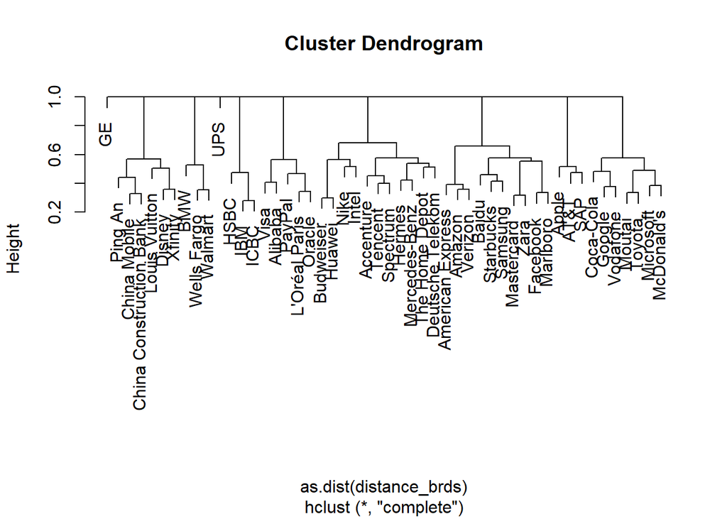

```r
# use hierarchical clustering
hc <- hclust(as.dist(distance_brds))

# visualize the dendrogram
plot(hc)
```

What does the plot say to you? Do you… * detect any ‘natural’ groupings? * Are same-country brands likely to be grouped together? Implying country specific naming conventions? * Are same-industry brands likely to be grouped together? Implying industry specific naming norms? * etc.

## Clustering R Package names

Another quick example. This link here contains the names of all R packages uploaded to CRAN.

https://cran.r-project.org/web/packages/available_packages_by_name.html

Below, we:

- scrape the names of all 14k+ R packages on CRAN,
- segregate them by string length and
- cluster them by `hclust` based on `stringdist`

Behold.

```r
library(rvest)
library(magrittr)
library(stringdist)

url1 = "https://cran.r-project.org/web/packages/available_packages_by_name.html"

# scrape the names
system.time({ a0 <- read_html(url1) %>% html_nodes('td a') %>% html_text()
    })  # 3.2 secs
```

```
##    user  system elapsed
##    0.86    0.00    3.27
```

```r
# extract all package names with 10 chars
a1 <- a0[(nchar(a0) == 10)]
package_names <- unique(as.character(sample(a1, 50)))

package_names[1:20]    # view a few
```

```
##  [1] "shinyrecap" "elasticnet" "time2event" "properties" "rstantools"
##  [6] "NetIndices" "ggpolypath" "quantileDA" "sperrorest" "LearnBayes"
## [11] "stsm.class" "provParseR" "data.world" "ggenealogy" "nowcasting"
## [16] "rapidraker" "multigraph" "KernSmooth" "taxonomizr" "mvglmmRank"
```

Now, let’s build a dist matrix and run hclust.

```r
distance_names <- stringdistmatrix(package_names, package_names, method = "jw")

rownames(distance_names) <- package_names

# examining the distance_brds object
dim(distance_names)
```

```
## [1] 50 50
```

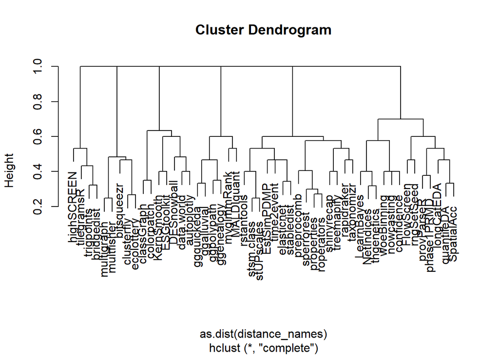

```r
# use hierarchical clustering
hc <- hclust(as.dist(distance_names))

# visualize the dendrogram
plot(hc)
```

Well, any patterns catch your eye? Can we say that package names clustered together due to spelling similarity are actually also similar in terms of operational domain?

What ther applications of this method come to mind?

Chalo. Will stop here. Back to the slides, folks.

Ciao

Sudhir